# Student File for Decision Tree

ME Bond

April 23, 2021

# Student File for Decision Tree

# Create necessary library code chunk

```r
library(dplyr)
library(datasets)
library(caTools)
library(party)
#library(margrittr)
library(rpart)
```

```r
library(rpart.plot)
```

# Step 1, Get the data

Go to https://raw.githubusercontent.com/guru99-edu/R-Programming/master/titanic_data.csv

- Assign path to this URL
- create titanic (lower case t !) using read.csv(path)
- Look at titanic and observe the variables etc. **use glimpse(titanic) or head(titanic)**

```r
path <- "https://raw.githubusercontent.com/guru99-edu/R-Programming/master/titanic_data.csv"
titanic <- read.csv(path)
```

*New r chunk for the next steps*

- set.seed(678)
- shuffle the data because it has an order. What is the order?
  1. Create a shuffle_vector
  2. Order titanic using the shuffle_vector
     - Recall how one could use [] and [ , ] titanic[ , ]
     - verify that titanic has changed

```r
set.seed(678)
rows <- sample(nrow(titanic))
titanic <- titanic[rows, ]
```

# Step 2, Clean the data set

- Keep these variables **pclass, survived, sex, age, sibsp, parch, fare, embarked** *BY removing 5 variables.*
- Create factor variables for pclass and survived
- Change the class of the variable *age* and *fare* to numeric
- Drop the NA’s **the command from webpage doesn’t work**

```r
titanic <- titanic %>% select(-c(home.dest, cabin, name, x, ticket)) %>% mutate(pclass = factor(pclass, levels = c(1,2,3), labels = c('Upper', 'Middle', 'Lower')), survived = factor(survived, levels =c(0, 1), labels = c('Died', 'Survived'))) %>% na.omit()
titanic[,4] <- as.numeric(as.character(titanic[,4]))
titanic[,7] <- as.numeric(as.character(titanic[,7]))
#clean_titanic %>% drop_na()
titanic <- na.omit(titanic)
glimpse(titanic)
```

```
## Rows: 1,045
## Columns: 8
## $ pclass   <fct> Upper, Lower, Lower, Middle, Lower, Middle, Lower, Lower, Upp~
## $ survived <fct> Survived, Died, Died, Died, Died, Died, Died, Died, Survived,~
## $ sex      <chr> "male", "male", "male", "male", "female", "female", "male", "~
## $ age      <dbl> 36.0, 42.0, 18.5, 44.0, 19.0, 26.0, 23.0, 28.5, 64.0, 36.5, 4~
## $ sibsp    <int> 1, 0, 0, 0, 1, 1, 0, 0, 0, 0, 1, 0, 0, 1, 0, 1, 0, 0, 0, 0, 0~
## $ parch    <int> 2, 0, 0, 0, 0, 1, 0, 0, 2, 2, 1, 0, 0, 0, 0, 1, 0, 0, 0, 0, 0~
## $ fare     <dbl> 120.0000, 8.6625, 7.2292, 13.0000, 16.1000, 26.0000, 7.8542, ~
## $ embarked <chr> "S", "S", "C", "S", "S", "S", "S", "S", "C", "S", "S", "S", "~
```

**Check the number of rows and columns of your clean_titanic** Does it match the webpage dimensions?

# Step 3,Create train/test set

- Creat a train and test set (80/20 split)

## First we will **Create a function that will split the df**

```r
#Train <- function(df, Split = 0.8, tr=TRUE) {
#  train <- sample.split(df, SplitRatio = Split)
#  if (tr == TRUE) {
#    return(subset(df, train == TRUE))
#  }else{
#    return(subset(df, train == FALSE))
#  }
#}
Train <- function(data, size = 0.8, train = TRUE) {
    n_row = nrow(data)
    total_row = size * n_row
    train_sample <- 1: total_row
    if (train == TRUE) {
        return (data[train_sample, ])
    } else {
        return (data[-train_sample, ])
    }
}
```

## *The function from the webpage will need to be debugged, and you should test your function in the Console before continuing*

- Obtain and verify the training and testing dataframes

```r
data_train <- Train(titanic)
data_test <- Train(titanic, 0.8, FALSE)
head(data_train)
```

```
##      pclass survived    sex  age sibsp parch     fare embarked
## 57    Upper Survived   male 36.0     1     2 120.0000        S
## 774   Lower     Died   male 42.0     0     0   8.6625        S
## 920   Lower     Died   male 18.5     0     0   7.2292        C
## 430  Middle     Died   male 44.0     0     0  13.0000        S
## 1012  Lower     Died female 19.0     1     0  16.1000        S
## 476  Middle     Died female 26.0     1     1  26.0000        S
```

```r
dim(data_train)
```

```
## [1] 836   8
```

```r
dim(data_test)
```

```
## [1] 209   8
```

```r
prop.table(table(data_train$survived))
```

```
##
##      Died  Survived
## 0.6004785 0.3995215
```

```r
prop.table(table(data_test$survived))
```

```
##
##      Died  Survived
## 0.5550239 0.4449761
```

- Install rpart and rpart.plot

# Step 4, Build the model

- create the “fit” model
- Get a plot and understand the plot *webpage may have errors in code*

*to get the rpart.plot() to plot), just rpart.plot(fit)*

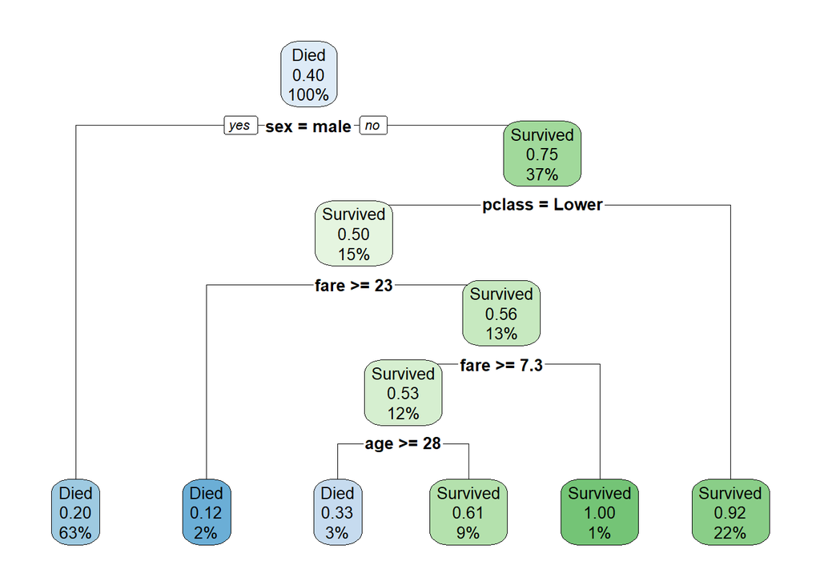

```r
fit <- rpart(survived~., data = data_train, method = 'class')
rpart.plot(fit, extra = 106)
```

# Step 5, Make a prediction

- predict using test set *understand predict unseen*
- Create a table to analyze your predictions
- Understand the table

```r
prediction <-predict(fit, data_test, type = 'class')
table <- table(data_test$survived, prediction)
table
```

```
##           prediction
##            Died Survived
##   Died      106       10
##   Survived   34       59
```

# Step 6, Measure performance

- Calculate and understand accuracy of your model

```r
accuracy_Test <- sum(diag(table)) / sum(table)
print(paste('Accuracy for test', accuracy_Test))
```

```
## [1] "Accuracy for test 0.789473684210526"
```

## This is the end of the lab

## For extra credit, do step 7, tune the hyper-parameters

# Step 7, Tune the hpyer-parameters